# Tutorium 5

Gruppen 5 und 7  
Samuel Teuber  
propa@teuber.dev  
https://teuber.dev/propa

# Übungsblätter

## Typen und Typklassen

```
fun1 xs = (xs == [])
fun2 f a = foldr f "a"
fun3 f a xs c = foldl f a xs c
fun4 f xs = map f xs xs
fun5 a b c = (maximum [a..b], 3 * c)
fun6 x y = succ (toEnum (last [fromEnum x..fromEnum y]))
fun7 x = if show x /= [] then x else error
```

```
fun1 xs = (xs == [])
```

```
fun1 :: (Eq t) => [t] -> Bool
```

```
fun2 f a = foldr f "a"
```

```
fun2 :: (Foldable c) => (a -> [Char] -> [Char]) -> b -> c a -> [Char]
```

```
fun3 f a xs c = foldl f a xs c
```

```
fun3 :: (Foldable t) => ((d -> e) -> a -> d -> e) -> (d -> e) -> t a -> d -> e
```

```
fun4 f xs = map f xs xs
```

**Nicht typisierbar:** Liste kann nicht auf xs *angewendet* werden

```
fun5 a b c = (maximum [a..b], 3 * c)
```

```
fun5 :: (Enum s, Ord s, Num t) => s -> s -> t -> (s, t)

-- What's Enum?
class Enum a where
    toEnum :: Int -> a
    fromEnum :: a -> Int
    -- ...
    succ :: a -> a
```

```
fun6 x y = succ (toEnum (last [fromEnum x..fromEnum y]))
```

```
fun6 :: (Enum a, Enum b, Enum c) => a -> b -> c
```

```
fun7 x = if show x /= [] then x else error
```

```
fun7 :: (Show ([Char] -> a)) => ([Char] -> a) -> ([Char] -> a)
-- weil:
error :: [Char] -> a
```

# Aufgabe 2: Abstrakte Syntaxbäume

Beispiel für eine Datenstruktur

```
data Exp t
    = Var t
    | Const Integer
    | Add (Exp t) (Exp t)
```

Beispiel für eine `eval` Funktion:

```
eval :: Env a -> Exp a -> Integer
eval env (Var v) = env v
eval env (Const c) = c
eval env (Add e1 e2) = (eval env e1) + (eval env e2)
```

# Aufgabe 2: Abstrakte Syntaxbäume

```
data Exp t
    = Var t
    | Const Integer
    | Add (Exp t) (Exp t)
    | Less (Exp t) (Exp t)
    | And (Exp t) (Exp t)
    | Not (Exp t)
    | If (Exp t) (Exp t) (Exp t)
    deriving Eq
```

# Aufgabe 2: Abstrakte Syntaxbäume

```
eval :: Env a -> Exp a -> Integer
eval env (Var v) = env v
eval env (Const c) = c
eval env (Add e1 e2) = (eval env e1) + (eval env e2)
eval env (Less e1 e2)
    | eval env e1 < eval env e2 = 1
    | otherwise = 0
eval env (And e1 e2)
    | eval env e1 == 0 || eval env e2 == 0 = 0
    | otherwise = 1
eval env (Not e1)
    | eval env e1 == 0 = 1
    | otherwise = 0
eval env (If b t e)
    | eval env b == 0 = eval env e
    | otherwise = eval env t
```

# Aufgabe 2: Abstrakte Syntaxbäume

```
instance Show a => Show (Exp a) where
    show (Var a) = show a
    show (Const i) = show i
    show (Add e1 e2) = "(" ++ show e1 ++ " + " ++ show e2 ++ ")"
    show (Less e1 e2) = "(" ++ show e1 ++ " < " ++ show e2 ++ ")"
    show (And e1 e2) = "(" ++ show e1 ++ " & " ++ show e2 ++ ")"
    show (Not e) = "!(" ++ show e ++ ")"
    show (If b t e) = "(" ++ show b ++ " ? " ++ show t ++ " : " ++ show e ++ ")"
```

# Aufgabe 3: Ropes: Länge

```
data Rope
= Leaf String
| Inner Rope Int Rope
```

```
ropeLength :: Rope -> Int
ropeLength (Leaf s) = length s
ropeLength (Inner _ w r) = w + ropeLength r
```

# Aufgabe 3: Ropes: Concat

```
data Rope
= Leaf String
| Inner Rope Int Rope
```

```
ropeConcat :: Rope -> Rope -> Rope
ropeConcat l r = Inner l (ropeLength l) r
```

# Aufgabe 3: Ropes: splitAt

```
data Rope
= Leaf String
| Inner Rope Int Rope
```

```
ropeSplitAt :: Int -> Rope -> (Rope, Rope)
ropeSplitAt i (Leaf s) = (Leaf (take i s), Leaf (drop i s))
ropeSplitAt i (Inner l w r)
    | i < w = let (ll, lr) = ropeSplitAt i l
                in (ll, ropeConcat lr r)
    | i > w = let (rl, rr) = ropeSplitAt (i-w) r
                in (ropeConcat l rl, rr)
    | otherwise = (l, r)
```

# Aufgabe 3: Ropes: Insert

```
data Rope
= Leaf String
| Inner Rope Int Rope
```

```
ropeInsert :: Int -> Rope -> Rope -> Rope
ropeInsert i s rope = l `ropeConcat` s `ropeConcat` r
    where (l, r) = ropeSplitAt i rope
```

# Aufgabe 3: Ropes: Delete

```
data Rope
= Leaf String
| Inner Rope Int Rope
```

```
ropeDelete i j r = ropeConcat a d
where
    (a, _) = ropeSplitAt i r
    (_, d) = ropeSplitAt j r
```

[figure not shown]

# Der untypisierte $\lambda$-Kalkül

**$\lambda$-Terme**

| Bezeichnung | Notation | Beispiele aus der Vorlesung |
| --- | --- | --- |
| Variablen | $x$ | $x$ $y$ $z$ |
| Abstraktion | $\lambda x. t$ | $\lambda f.\lambda x. f x$ |
| Funktionsanwendung | $t_1 t_2$ | $f y$ |

- Funktionsanwendung linksassoziativ
- Funktionsanwendung bindet stärker als Abstraktion

$$ \lambda f. \lambda x.f x y $$

Wo würden hier die Klammern sitzen?

$$ \lambda f. \left( \lambda x.\left(\left(f\ x\right)\ y\right)\ \right) $$

# $\lambda$-Terme: Keine Strings

$$ \lambda x.f\ x\ y $$

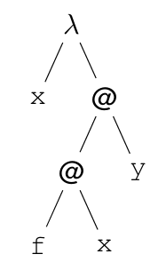

$$ (\lambda x.f\ x)\ y \neq \mathbf{\lambda x.f\ x\ y} = \lambda x.(f\ x\ y) $$

# $\alpha$-Äquivalenz

> $t_1$ und $t_2$ heißen $α$-äquivalent, wennt $t_1$ in $t_2$ durch konsistente Umbenennung der λ-gebundenen Variablen ̈uberfuhrt werden kann.

=> Isomorphismus zwischen den Syntaxbäumen

**Beispiel:** $$ \lambda x.(\lambda z.f(\lambda y.z\ y)\ x)=^\alpha\lambda y.(\lambda x.f(\lambda z.x\ z)\ y) $$

# $\eta$-Äquivalenz

**Extensionalitäts-Prinzip:** 2 Funktionen gleich, wenn Ergebnis für alle Argumente gleich

> Terme $λx.f\ x$ und $f$ heißen $\eta$-aquivalent, falls $x$ nicht freie Variable von f **Beispiel:**
> - **$\eta$-äquivalent:** $f\ z$ und $\lambda x. f\ z\ x$
> - **nicht $\eta$-äquivalent:** $g\ x$ und $\lambda x. g\ x\ x$

# Ausführung von $\lambda$-Termen

- **Redex** ist ein $\lambda$-Term der Form $(\lambda x.t_1)\ t_2$
- **Substitution** $t_1\left[x\mapsto t_2\right]$ ersetzt in $t_1$ alle *freien* Vorkommen von $x$ durch $t_2$
- **$\beta$-Reduktion** entspricht einer Funktionsanwendung:  
  $\left(\lambda x.t_1\right) t_2 \Rightarrow t_1 \left[x \mapsto t_2\right]$
- **Normalform** ist ein Term, der nicht weiter reduziert werden kann

# Warum ist der $\lambda$-Kalkül so cool?

- Turingmächtiges Berechnungsmodell
- In den 1930er Jahren ohne (!) Computer entwickelt
- Sehr simple Semantik, aber trotzdem sehr mächtig

# Tücken in der Substitution

# Übung zu $\beta$-Reduktionen

# Auswertungsstrategien

- **Normalreihenfolge**: Immer der linkeste äußerste Redex wird reduziert
- **Call-by-Name**: Linkesten, äußeren Redex aber nicht, wenn von $\lambda$ umgeben
- **Call-by-Value**: Linkesten Redex, der nicht von $\lambda$ umgeben, dessen Argument *Wert* ist

# Church Rosser Eigenschaft

> Der untypisierte $\lambda$-Kalkül ist konfluent:  
> Wenn $t \Rightarrow^* t_1$ und $t \Rightarrow^* t_2$,  
> dann gibt es ein $t'$ mit $t_1 \Rightarrow^* t'$ und $t_2 \Rightarrow^* t'$

# Eindeutigkeit der Normalform

> Die Normalform eines $\lambda$-Terms $t$ ist - sofern sie existiert - eindeutig.

# Auswertungsstrategien vol. 2

- Call-by-Name und Call-by-Value werten nicht immer zu Normalform aus, aber darauf $\beta$-reduzierbar
- Call-by-Name ist quasi Lazy Evaluation
- Call-by-Name terminiert öfter

# **ALLES** sind Funktionen

# Fibonacci Zahlen im $\lambda$-Kalkül

einfach weil es halt geht...

```haskell
fun1 :: Eq t => [t] -> Bool
fun1 xs = (xs == [])
```

Redundant bracket

Found:

(xs == [])

Why Not:

xs == []

Use null

Found:

xs == []

Why Not:

null xs

```haskell
instance (Show a) => Show ([Char] -> a) where
    show :: ([Char] -> a) -> [Char]
    show x = x "hi"

test :: [Char] -> Char
test x = 'c'

show test
```

Use String

Found:

([Char] -> a) -> [Char]

Why Not:

(String -> a) -> String

Use String

Found:

[Char] -> Char

Why Not:

String -> Char

[output not shown]

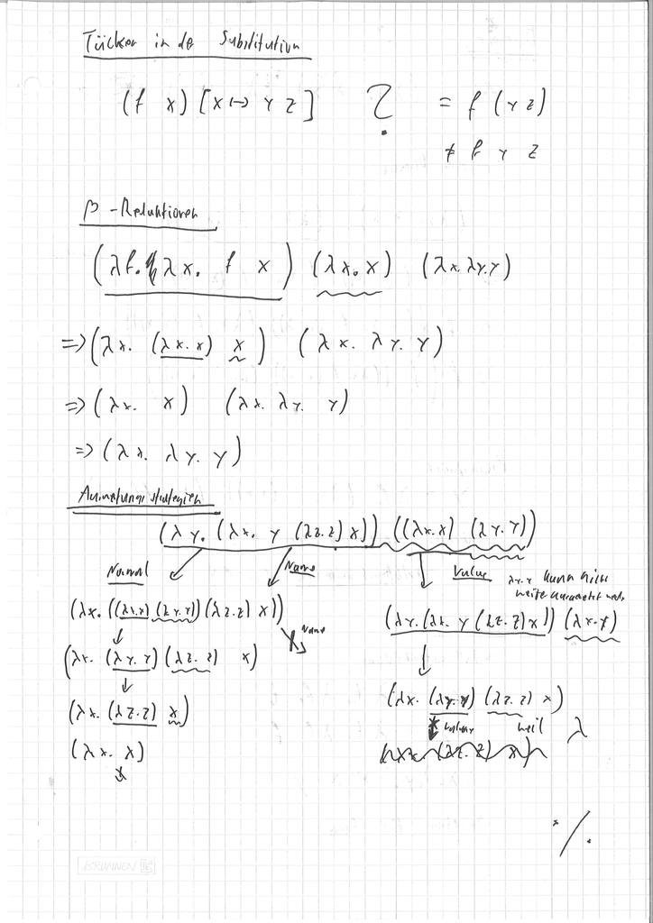

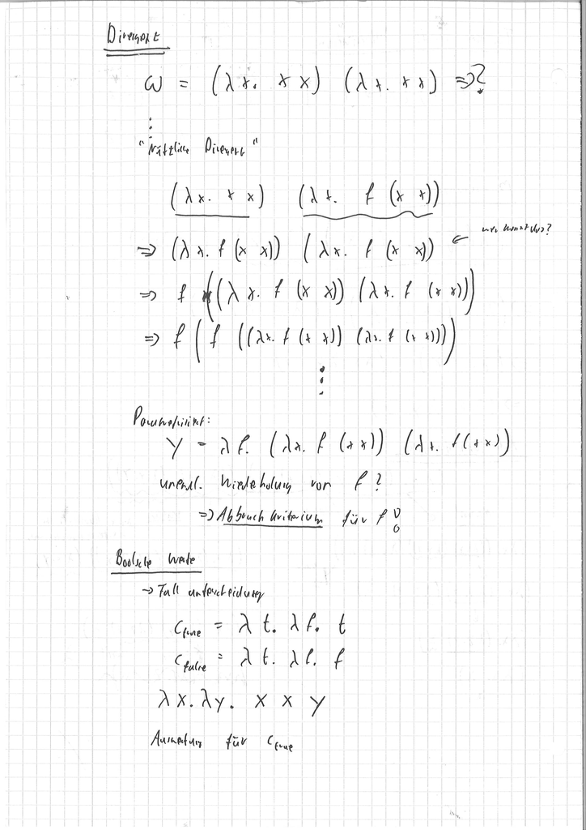

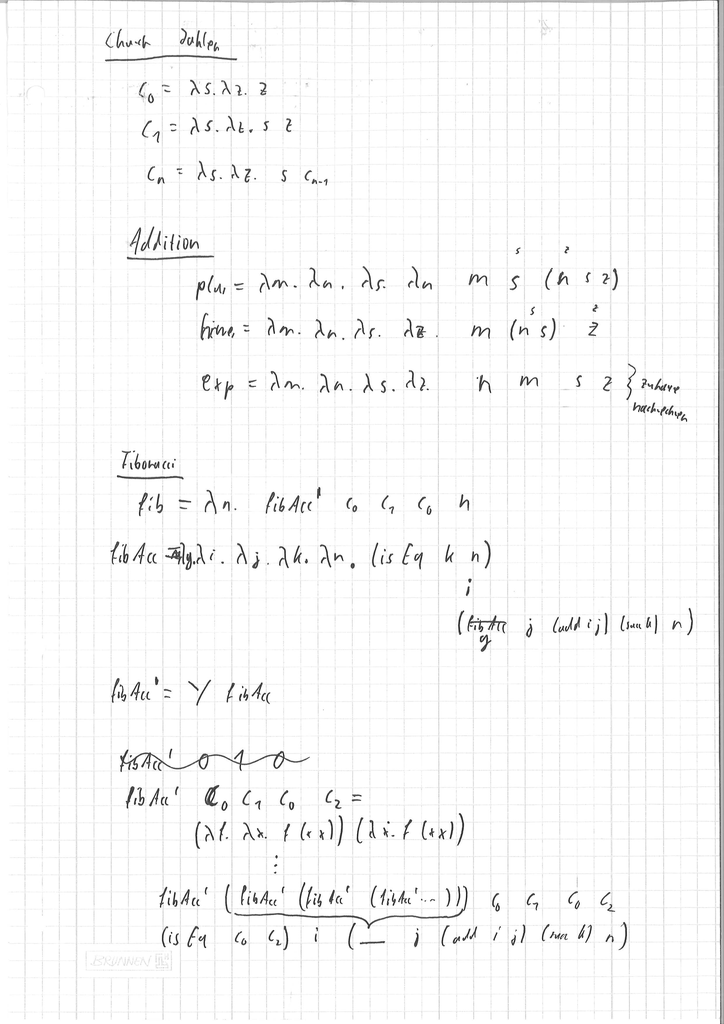